# Sentiment on Economy

Abhijith

6/28/2021

```r
library(rtweet)
library(ggplot2)
library(dplyr)
library(tidytext)
library(tm)
library(textdata)
library(wordcloud)
library(syuzhet)
library(RColorBrewer)
library(SnowballC)
library(RCurl)
library(xml2)
library(wordcloud2)
library(qdapRegex)
library(stringr)
```

connecting to twitter API

```r
twitter_token<-create_token(app = app_name,consumer_key=key,consumer_secret = secret,access_token = access,access_secret = accesssecr)
twitter_token
```

```
## <Token>
## <oauth_endpoint>
##  request:   https://api.twitter.com/oauth/request_token
##  authorize: https://api.twitter.com/oauth/authenticate
##  access:    https://api.twitter.com/oauth/access_token
## <oauth_app> abhijith_senti
##   key:    tqJ3SCw4tEr2LlsXqQ47JlisV
##   secret: <hidden>
## <credentials> oauth_token, oauth_token_secret
## ---
```

To get all the tweets with “economy” keyword in it and I decided not to include retweets in this

```r
tweet_econ<-search_tweets(q="economy",n=2000,include_rts = FALSE)
```

only taking text column and seperating it as individual vector

```r
tweet_text<-str_c(tweet_econ$text,collapse="")
```

cleaning

```r
tweet_text<-tweet_text %>% str_remove("\\n") %>% rm_twitter_url() %>% rm_url() %>%  str_remove_all("@\\S+") %>% str_remove_all("#\\S+") %>% removeWords(stopwords("english")) %>% removeNumbers() %>% stripWhitespace() %>% removeWords(c("amp","t.co","the","will")) %>% str_remove_all(".,") %>%removePunctuation() %>% wordStem(language = "english")
```

converting the cleaned document into a form of Matrix

```r
text_summ <- Corpus(VectorSource(tweet_text)) %>% TermDocumentMatrix() %>% as.matrix()
text_summ<-sort(rowSums(text_summ),decreasing=TRUE)
```

Getting individual data frame of words with the count for wordcloud

```r
text_summ<- data.frame(word=names(text_summ),freq=text_summ,row.names=NULL)
text_summ
```

[output not shown]

Using wordcloud2 package, to create a wordcloud

```r
word_cloud<-wordcloud2(data=text_summ,minRotation = 0,maxRotation = 0,ellipticity = 0.6)

word_cloud
```

[interactive chart not shown]

Now since we got the wordcloud. We will get back to sentiment analysis Cleaning the document in total again, especially text column

```r
econ_tweet<-tweet_econ%>% select(screen_name,text)
econ_tweet$s_text<-gsub("https","",econ_tweet$text)
econ_tweet$s_text<-gsub("t.co","",econ_tweet$s_text)
econ_tweet$s_text<-gsub("\\|","",econ_tweet$s_text)
econ_tweet$s_text<-gsub("@","",econ_tweet$s_text)
econ_tweet$s_text<-gsub("/","",econ_tweet$s_text)
```

Stemming,removing numbers and punctations using tm package,textdata package and snowballC

```r
econ_tweet$s_text<-econ_tweet$s_text %>% wordStem(language="english") %>% removeNumbers() %>% removePunctuation() %>% removeWords(stopwords("english"))
```

Removing common english stopwords for the convenience of analysis

```r
econ_twitter<-econ_tweet %>% select(s_text) %>% unnest_tokens(word,s_text)
economy_twitter<-econ_twitter %>% anti_join(stop_words)
```

Using tidytext and dplyr by using bing,afinn lexicons we can run our sentiment analysis using bing lexicon and ggplot we can see what are most negative tweets and most positive tweets

```r
bing_econ<-economy_twitter %>% inner_join(get_sentiments("bing")) %>% count(word,sentiment,sort= TRUE) %>% ungroup()
```

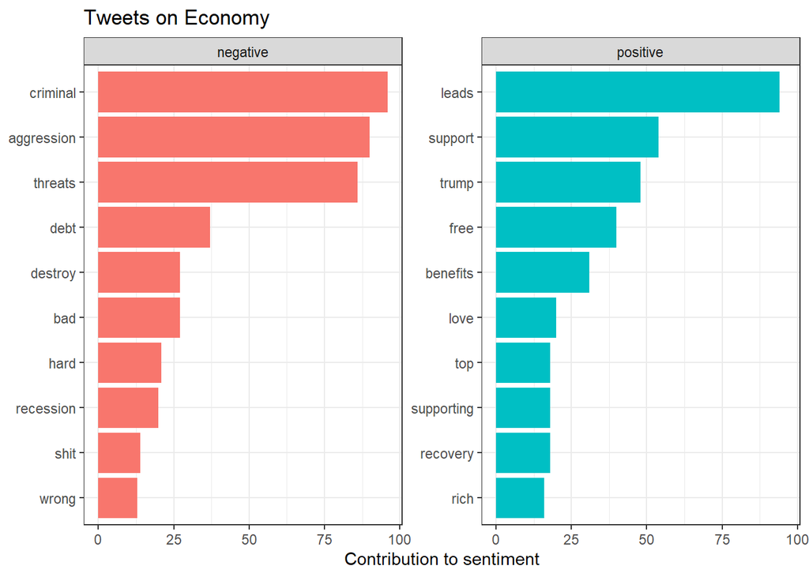

```r
bing_econ%>% group_by(sentiment) %>% top_n(10) %>% ungroup() %>% mutate(word=reorder(word,n)) %>% ggplot(aes(word,n,fill=sentiment))+geom_col(show.legend=FALSE)+facet_wrap(~sentiment,scales="free_y")+labs(title="Tweets on Economy",y="Contribution to sentiment",x=NULL)+coord_flip()+theme_bw()
```

```r
ggsave("Contribution to sentiment economy.png")
```

```r
affin_econ<-economy_twitter %>% inner_join(get_sentiments("afinn")) %>% count(word,value,sort=TRUE) %>% ungroup()
```

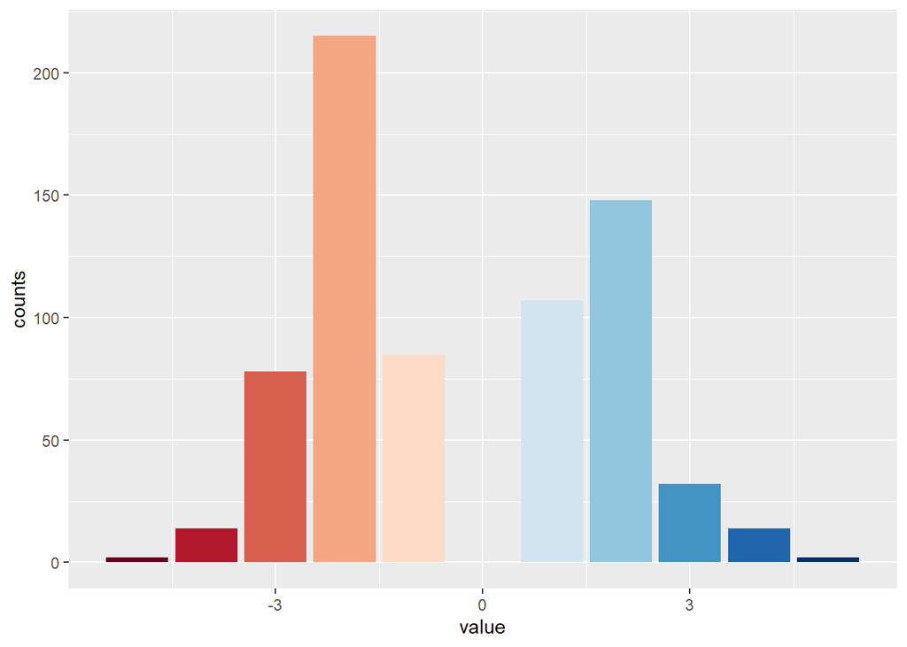

```r
affin_econ<-affin_econ %>% group_by(value) %>% summarise(counts=n())
affin_econ %>% ggplot(aes(x=value,y=counts,fill=as.factor(value)))+geom_bar(stat="identity",position=position_stack(),show.legend = FALSE)+scale_fill_brewer(type="Diverging",palette="RdBu",direction=1,aesthetics="fill")
```